# Delhi return levels

## Extract time series

First step is to extract yearly maxima and daily time series for a single location using IMD gridded precipitation data for the years 1901-2017.

```r
library(ncdf4)
library(extRemes)
f <- "/home/abhi/Documents/data/OBSERVATION/IMD/precip/1901-2017_ll25.nc"

# Delhi
p.lon <- 77.10
p.lat <- 28.70

## Yearly maximum time series
system(paste("cdo -yearmax -remapnn,lon=",p.lon,"_lat=",p.lat, " ", f, " /tmp/point_ymax.nc", sep=""))
```

```
cdo(2) remapnn: Process started
cdo(2) remapnn: Nearest neighbor weights from lonlat (135x129) to lonlat (1x1) grid, with source mask (4964)
cdo(2) remapnn: Processed 744212610 values from 1 variable over 42734 timesteps
cdo yearmax: Processed 42734 values from 1 variable [17.94s 34MB]
```

```r
## Daily time series
system(paste("cdo -remapnn,lon=",p.lon,"_lat=",p.lat, " ", f, " /tmp/point.nc", sep=""))
```

```
cdo remapnn: Nearest neighbor weights from lonlat (135x129) to lonlat (1x1) grid, with source mask (4964)
cdo remapnn: Processed 744212610 values from 1 variable over 42734 timesteps [4.82s 47MB]
```

```r
## Read netcdf files
nc.p.ymax <- nc_open("/tmp/point_ymax.nc")
nc.station <- nc_open("/tmp/point.nc")

## Get the rainfall variable
rf.p.ymax <- ncvar_get(nc.p.ymax, "rf")
rf.p <- ncvar_get(nc.station, "rf")
```

## 1. Block Maxima approach

Delhi : Annual maxima Precipitation time series 1901-2017

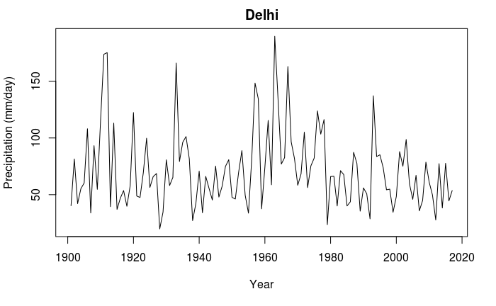

```r
years <- 1901:2017
plot(years, rf.p.ymax, type="l", ylab="Precipitation (mm/day)", xlab="Year", main="Delhi")
```

### Fit the block maxima to GEV distribution.

The GEV df is given by,  
$G(x) = exp[-\{1 + \xi(\dfrac{x - u}{\sigma})\}^{-1/\xi}]$,  
which in the limit $\xi \longrightarrow 0$ results in the Gumbel distribution given by,  
$G(x) = exp[-exp\{-(\dfrac{x-u}{\sigma})\}]$

$Type \hspace{0.1cm} I$ **Gumbel**: $\xi = 0$  
$Type \hspace{0.1cm} II$ **Fretchet**: $\xi > 0$, Heavy tailed  
$Type \hspace{0.1cm} III$ **Upper bounded Weibull**: $\xi < 0$, (reverse or reflected Weibull)

The estimated parameters $\mu$, $\sigma$ and $\xi$ are fitted using MLE. The standard error of the ML estimators along with the parameter covariance matrix is also shown. Finally AIC and BIC are information criteria to determine the goodness of model fit (lower the better).  
Since $\xi > 0$, we have a $Type \hspace{0.1cm}II$ i.e. Fretchet distribution

```r
fit <- fevd(rf.p.ymax, units = "mm/day")
fit
```

```
fevd(x = rf.p.ymax, units = "mm/day")

[1] "Estimation Method used: MLE"


 Negative Log-Likelihood Value:  561.5325


 Estimated parameters:
  location      scale      shape
55.4454073 23.4215106  0.1149053

 Standard Error Estimates:
  location      scale      shape
2.47427009 1.89183438 0.07758678

 Estimated parameter covariance matrix.
            location       scale        shape
location  6.12201247  2.37445225 -0.068091417
scale     2.37445225  3.57903732 -0.030225593
shape    -0.06809142 -0.03022559  0.006019708

 AIC = 1129.065

 BIC = 1137.351
```

### Plot the fit.

1. qqplot
2. qqplot2 with regression line (with 95% confidence interval), 1:1 line.
3. Compare empirical density v/s GEV probability distribution
4. Return level plot for different return periods.

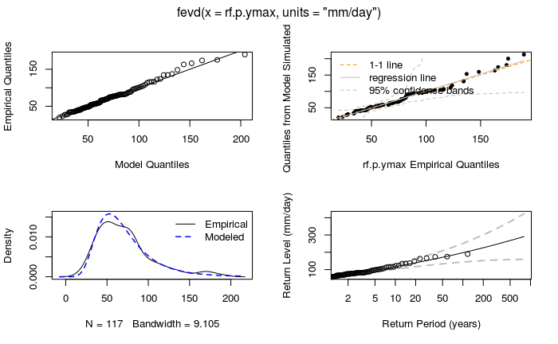

```r
plot(fit)
```

### Return level estimates

Estimate return levels for different return periods. The confidence intervals are based on normal approximation of the return level estimator.

```r
return.level(fit, return.period = c(2, 5, 10, 20, 50, 100), do.ci=TRUE)
```

```
fevd(x = rf.p.ymax, units = "mm/day")

[1] "Normal Approx."

                      95% lower CI  Estimate 95% upper CI
2-year return level       58.61422  64.21302     69.81181
5-year return level       84.63466  93.78537    102.93609
10-year return level     101.54976 115.59426    129.63875
20-year return level     116.51940 138.35716    160.19492
50-year return level     133.41028 170.76035    208.11042
100-year return level    143.83995 197.42013    251.00031
```

Calculating return levels from a GEV distribution.

We need to find the probability of exceeding certain precipitation amount *x* which exceeds every *m* years. This implies, that the probability of precipitation exceeding amount *x* is $1/m$.

$P(X > x) = 1 - P(X \le x)$, ($X:$ Annual maximum precipitation)  
For an *m* year return period, we have $P(X > x) = 1/m$,  
Hence we have, $1/m = 1 - P(X \le x)$  
$\implies P(X \le x) = 1 - 1/m$,  
We have estimated the *CDF* of $X$, by fitting the block maxima to a *GEV* distribution.  
So, we have $X \sim GEV(x \hspace{0.1cm} |\hspace{0.1cm} \mu, \sigma, \xi)$  
So, from the *CDF* of X, we need to find $1 - 1/m$ quantile.

```r
# Make Fit object easier to manage
fit.distilled <- distill(fit)

for (param in c("location", "scale", "shape")){
  assign(param, fit.distilled[param])
}

# get 1 - 1/m quantile from the cdf
## Calculate 2, 5, 10, 20, 50, 100 year return levels
rperiods <- c(2, 5, 10, 20, 50, 100)
rlevs <- c()
for (m in rperiods){
   rlevs<- c(rlevs, qevd(1 - 1/m, location, scale, shape, type = "GEV"))
}
names(rlevs) <- paste0(rperiods, "-year level")
print(rlevs)
```

```
  2-year level   5-year level  10-year level  20-year level  50-year level 100-year level
      64.21302       93.78537      115.59426      138.35716      170.76035      197.42013
```

Which is the same as calculated by the package.

```r
rlevs <- as.vector(return.level(fit, return.period = rperiods))
names(rlevs) <- paste0(rperiods, "-year level")
print(rlevs)
```

```
  2-year level   5-year level  10-year level  20-year level  50-year level 100-year level
      64.21302       93.78537      115.59426      138.35716      170.76035      197.42013
```

### Parameter estimates

The confidence intervals are based on normal approximation of the parameter estimators.

```r
ci(fit, type="parameter")
```

```
fevd(x = rf.p.ymax, units = "mm/day")

[1] "Normal Approx."

         95% lower CI   Estimate 95% upper CI
location  50.59592699 55.4454073   60.2948875
scale     19.71358335 23.4215106   27.1294378
shape     -0.03716198  0.1149053    0.2669726
```

#### Demonstrate confidence interval for the shape parameter using normal approximation.

The answer comes out to be same as calcuated by the package function ci.

```r
xi.mean <- distill(fit)["shape"]
xi.sd <- sqrt(distill(fit)["shape.shape"])
# 95% confidence interval
qnorm(c(0.025, 0.975), xi.mean, xi.sd)
```

```
[1] -0.03716198  0.26697261
```

#### Profile likelihood

1. Plot Log likelihood plots of the parameters and its gradient for each parameter.  
   **Note**: For each paramter this holds other parameters at their MLE.  
   This is important for deriving confidence intervals of the parameter estimates in the case when the log likelihood is not symmetrical about MLE.

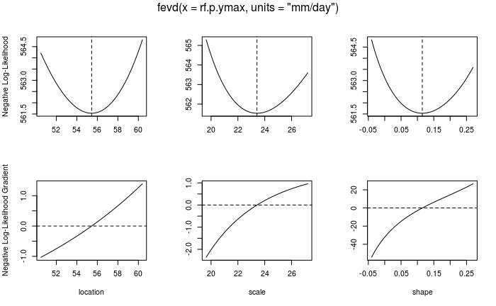

```r
plot(fit, "trace")
```

2. Obtain ci based on profile likelihood method by specifying the range in which to look for the confidence interval

First let’s print out the normal approx. confidence interval for $\xi$ i.e. the shape parameter.

```r
ci(fit, type="parameter", which.par = 3, method="normal")
```

```
fevd(x = rf.p.ymax, units = "mm/day")

[1] "Normal Approx."

[1] "shape: 0.115"

[1] "95% Confidence Interval: (-0.0372, 0.267)"
```

Now let’s calculate it using profile likelihood method.  
**NOTE**: Different ranges in which to look will produce slightly different confidence intervals. I don’t know how to specify a good range to look for the confidence interval. This is usually determined by trial and error by looking at the profile likelihood plot.

```r
ci(fit, type="parameter", which.par = 3, xrange = c(-0.4, 0.6), method="proflik")
```

```
fevd(x = rf.p.ymax, units = "mm/day")

[1] "Profile Likelihood"

[1] "shape: 0.115"

[1] "95% Confidence Interval: (-0.0236, 0.2794)"
```

Now let’s calculate the confidence intervals for return level estimates 1. Normal approximation

```r
return.level(fit, return.period = 50, do.ci = T, method="normal")
```

```
fevd(x = rf.p.ymax, units = "mm/day")

[1] "Normal Approx."

[1] "50-year return level: 170.76"

[1] "95% Confidence Interval: (133.4103, 208.1104)"
```

2. Profile likelihood method  
   The profile likelihood plot should have the confidence interval within the range used and not merely be endpoints of the range specified.

```
 Preparing to calculate  95 % CI for  50-year return level

 Model is   fixed

 Using Profile Likelihood Method.

 Calculating profile likelihood.  This may take a few moments.

 Profile likelihood has been calculated.  Now, trying to find where it crosses the critical value =  -563.4532
fevd(x = rf.p.ymax, units = "mm/day")

[1] "Profile Likelihood"

[1] "50-year return level: 170.76"

[1] "95% Confidence Interval: (143.827, 225.7948)"
```

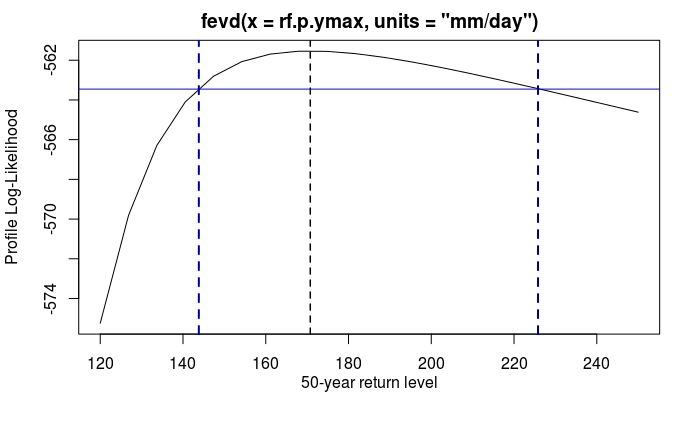

```r
ci(fit, which.par = 3, return.period = 50, xrange = c(120, 250), method = 'proflik', verbose = T)
```

### Return levels for particular amount of rainfall

```r
# Precipitation amounts for which to find return levels
precip.v <- seq(100, 200, 20)

# Probability of exceeding
prob.exceedance <- pextRemes(fit, q = precip.v, lower.tail = FALSE)
prob.exceedance
```

```
[1] 0.163881527 0.087188652 0.047633577 0.026862097 0.015635913 0.009376567
```

```r
# Return period (in years)
fit.rlevels <- 1/prob.exceedance
names(fit.rlevels) <- paste(precip.v, "mm")
fit.rlevels
```

```
    100 mm     120 mm     140 mm     160 mm     180 mm     200 mm
  6.101969  11.469382  20.993594  37.227176  63.955332 106.648846
```

### Likelihood ratio test

Note that the 95 % confidence interval gives a range whose lower bound goes to negative. This means that $\xi$ could be 0. We know that when $\xi$ = 0, we have a gumbel distribution. To test this we perform a likelihood ratio test.  
$H_o$ : The distribution is Gumbel.  
$H_a$ : The distribution is Fretchet  
Note: The model with the fewer parameters is always (mostly) the Null Hypothesis. Because a model with 3 parameters (i.e. Fretchet ($\mu, \sigma, \xi$)) is *more complex* than a model with 2 parameters (i.e. Gumbel ($\mu, \sigma$)), and in statistics we penalize complexity, hence $H_o$ is Gumbel and $H_a$ is Fretchet.

1. Fit to a gumbel distribution

```r
fit.gumbel <- fevd(rf.p.ymax, type = "Gumbel", units = "mm/day")
fit.gumbel
```

```
fevd(x = rf.p.ymax, type = "Gumbel", units = "mm/day")

[1] "Estimation Method used: MLE"


 Negative Log-Likelihood Value:  562.7949


 Estimated parameters:
location    scale
56.94341 24.59385

 Standard Error Estimates:
location    scale
2.384914 1.835752

 Estimated parameter covariance matrix.
         location    scale
location 5.687817 1.322044
scale    1.322044 3.369985

 AIC = 1129.59

 BIC = 1135.114
```

2. Likelihood ratio test  
   The p-value is high in our case (0.1121). This means at 90% confidence level (i.e. $\alpha = 0.1$), we can’t reject $H_o$.  
   Does this mean, we should use Gumbel to model the block maxima, as oppossed to the originally fitted model Fretchet?

```r
lr.test(fit, fit.gumbel)
```

```
    Likelihood-ratio Test

data:  rf.p.ymaxrf.p.ymax
Likelihood-ratio = 2.5248, chi-square critical value = 3.8415, alpha = 0.0500, Degrees of Freedom
= 1.0000, p-value = 0.1121
alternative hypothesis: greater
```

### Fit using L-moments approach (estimation of parameters)

```r
fitLM <- fevd(rf.p.ymax, method = "Lmoments")
fitLM
```

```
fevd(x = rf.p.ymax, method = "Lmoments")
[1] "GEV  Fitted to  rf.p.ymax  using L-moments estimation."
  location      scale      shape
55.4714407 23.9035821  0.1003739
```

```r
ci(fitLM)
```

```
fevd(x = rf.p.ymax, method = "Lmoments")

[1] "Parametric Bootstrap"
502  iterations

[1] "100-year level: 195.221"

[1] "95% Confidence Interval: (153.3998, 248.331)"
```

```r
ci(fitLM, type = "parameter")
```

```
fevd(x = rf.p.ymax, method = "Lmoments")

[1] "Parametric Bootstrap"
502  iterations

                2.5%   Estimate      97.5%
location 51.00973047 55.4714407 60.3639574
scale    20.16579657 23.9035821 28.2598482
shape    -0.05305752  0.1003739  0.2366786
```

## 2. Peak over threshold approach

The GP df is given by,  
$H(x) = 1 - [1 + \xi(\dfrac{x-u}{\sigma_u})]^{-1/\xi}$  
This has the same interpreation as GEV df,  
heavy tail when $\xi > 0$ (Pareto),  
upper bound when $\xi < 0$ (Beta), and  
exponential in the limit as $\xi \longrightarrow 0$, which results in  
$H(x) = 1 - e^{-(x-u)/\sigma}$  
Delhi : Daily precipitation time series 1901-2017

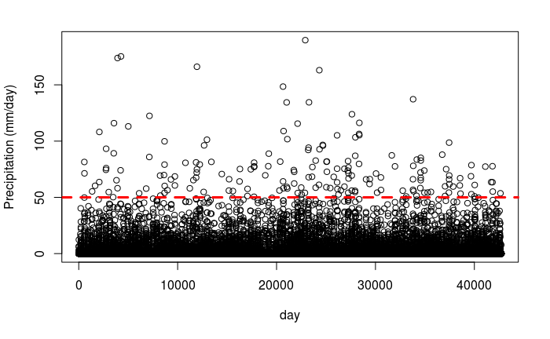

```r
# set any arbitrary threshold to visualize excesses
set.thresh <- 50
plot(rf.p, xlab = "day", ylab = "Precipitation (mm/day)"); abline(set.thresh, 0, col="red", lwd=3, lty=2)
```

### Threshrange plot

Repeatedly fits the GP df to the data for a sequence of threshold choices. Confidence interval bands are shown as bars.

**Bias** : Too low a threshold, implies the asymptotic assumption becomes invalid however the amount of data samples is high thereby reducing the uncertainty (variance) in the estimate (short bars) .

**Variance** : Too high a threshold, implies the asymptotic assumption becomes valid however the too less data samples mean a high uncertainty in the estimate (long bars).

**Reparameterized scale** : $\sigma^{*} = \sigma (u) - \xi u$, adjusted so that it is not a function of the threshold.

The mean of the GP df is given by $E[X - u | X > u] = \sigma (u)/ (1- \xi) = (\sigma (u_{o}) + \xi u)/(1- \xi)$, which is a linear function of the threshold.

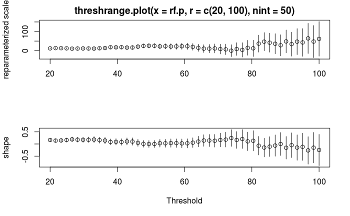

```r
threshrange.plot(rf.p, r = c(20, 100), nint = 50)
```

### Mean excess

The mean excess above a threshold is defined as  
$e_X(u) = \sum_{i=1}^{n_u} (x_i - u)$  
where $x_i, ...., x_{n_{u}}$ are observations that exceed the threshold $u$. If the exceedances of a threshold u0 are generalized Pareto, the empirical mean residual life plot should be approximately linear for u > u0.

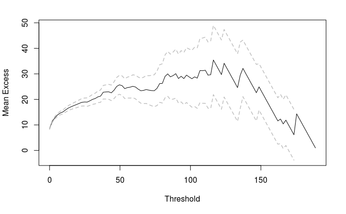

```r
mrlplot(rf.p)
```

Does **50** (mm) look like an appropriate threshold?  
Let’s check the number of data points above 50

```r
set.thresh <- 50
print(paste("The number of data points above", set.thresh, "mm is", length(rf.p[rf.p > set.thresh])))
```

```
[1] "The number of data points above 50 mm is 178"
```

```r
print(paste(set.thresh, "mm  corresponds to",
            round(ecdf(rf.p)(set.thresh)*100, 2),
            "percentile of the data"))
```

```
[1] "50 mm  corresponds to 99.58 percentile of the data"
```

### Make a dataframe

This will make things easier later.

```r
library(lubridate)
# Extract time vector
t.v <- ncdf4.helpers::nc.get.time.series(nc.station)

# Make the df
rf.p.df <- data.frame(obs = 1:length(rf.p), tobs = yday(t.v),
                      month = month(t.v), day = day(t.v), year = year(t.v),
                      Prec = rf.p)

# Print the df
print(as.matrix(rf.p.df), quote = FALSE, max = 100)
```

```
           obs tobs month day year        Prec
    [1,]     1    1     1   1 1901   6.4480839
    [2,]     2    2     1   2 1901   0.0000000
    [3,]     3    3     1   3 1901   0.0000000
    [4,]     4    4     1   4 1901   0.0000000
    [5,]     5    5     1   5 1901   0.0000000
    [6,]     6    6     1   6 1901   0.0000000
    [7,]     7    7     1   7 1901   0.0000000
    [8,]     8    8     1   8 1901   0.3073047
    [9,]     9    9     1   9 1901   2.6404133
   [10,]    10   10     1  10 1901   0.0000000
   [11,]    11   11     1  11 1901   0.0000000
   [12,]    12   12     1  12 1901   0.0000000
   [13,]    13   13     1  13 1901   6.0357594
   [14,]    14   14     1  14 1901  12.3524542
   [15,]    15   15     1  15 1901   2.9970300
   [16,]    16   16     1  16 1901   0.0000000
 [ reached getOption("max.print") -- omitted 42718 rows ]
```

### Fit the excesses 1

```r
# By default the time units for the event are 365.25/year
# Since we have daily data, we don't need to specify them explicitly.
fit.pot1 <- fevd(Prec, rf.p.df, threshold = 50, type = "GP", units = "mm")
fit.pot1
```

```
fevd(x = Prec, data = rf.p.df, threshold = 50, type = "GP", units = "mm")

[1] "Estimation Method used: MLE"


 Negative Log-Likelihood Value:  756.8037


 Estimated parameters:
      scale       shape
26.23545953 -0.01540403

 Standard Error Estimates:
    scale     shape
2.7164136 0.0714399

 Estimated parameter covariance matrix.
           scale       shape
scale  7.3789026 -0.13613437
shape -0.1361344  0.00510366

 AIC = 1517.607

 BIC = 1523.971
```

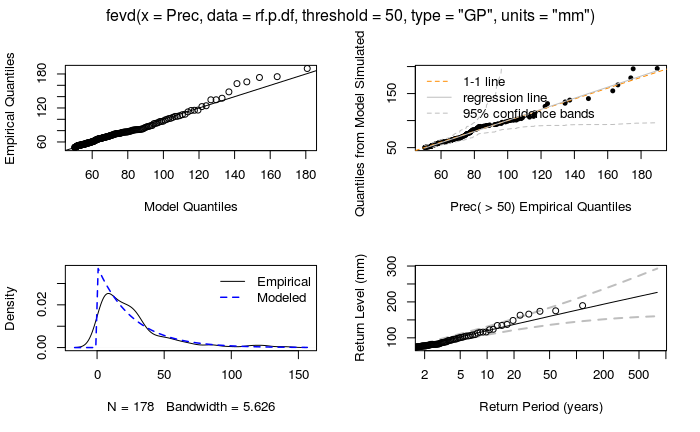

```r
plot(fit.pot1)
```

We can calculate the return levels for the POT fit.

```r
return.level(fit.pot1, rperiods)
```

```
fevd(x = Prec, data = rf.p.df, threshold = 50, type = "GP", units = "mm")
get(paste("return.level.fevd.", newcl, sep = ""))(x = x, return.period = return.period)
[1] "GP model fitted to Prec (mm)"
Data are assumed to be  stationary
[1] "Covariate data = rf.p.df"
[1] "Return Levels for period units in years"
  2-year level   5-year level  10-year level  20-year level  50-year level 100-year level
      78.94506      102.40983      119.94151      137.28700      159.93408      176.85483
```

Calculating return levels for a *GPD* fit is a little bit different. We know the excess (peaks) above a threshold $u$, follow a *GPD* distribution.  
**Final Goal** : We need to find the probability of exceeding a certain precipitation amount *x* which exceeds every *m* years.  
$prob(X \le x \hspace{0.1cm}|\hspace{0.1cm} X > u) = GPD(x-u\hspace{0.1cm}| \hspace{0.1cm} \sigma, \xi)$  
$prob(X > x \hspace{0.1cm}|\hspace{0.1cm} X > u) = 1 - GPD(x-u\hspace{0.1cm}| \hspace{0.1cm} \sigma, \xi)$

We know, $P(X > x\hspace{0.1cm}| \hspace{0.1cm} X > u) = \dfrac{P(X> x,X> u)}{P(X > u)}$  
But, $P(X >x, X>u) = P(X>x)$, $\implies P(X > x\hspace{0.1cm}| \hspace{0.1cm} X > u) = \dfrac{P(X> x)}{P(X > u)}$  
Simplyfying we get, $P(X > x\hspace{0.1cm}) = P(X > u)\cdot P(X> x \hspace{0.1cm} | \hspace{0.1cm}X> u)$  
$\implies P(X > x) = P(X > u)\cdot (1 - GPD(x-u\hspace{0.1cm}| \hspace{0.1cm} \sigma, \xi))$  
We can find $P(X >u)$ empirically (withput fitting the data) by calculating the number of data points above $u$.  
Since, in our case, the frequency of data points is daily, we have the probability of exceeding the precipitation amount *x* on any day of the year, $P(X > x) = P(X > u)\cdot (1 - GPD(x-u\hspace{0.1cm}| \hspace{0.1cm} \sigma, \xi))$  
For an *m*-year return period, $P(X > x) = \dfrac{1}{m} \cdot \dfrac{1}{365.25}$,  
$\implies \dfrac{1}{m} \cdot \dfrac{1}{365.25} = P(X > u)\cdot (1 - GPD(x-u\hspace{0.1cm}| \hspace{0.1cm} \sigma, \xi)$  
$\implies GPD(x-u\hspace{0.1cm}| \hspace{0.1cm} \sigma, \xi) = 1-(\dfrac{1}{m} \cdot \dfrac{1}{365} \cdot \dfrac {1}{P(X > u)})$

i.e. we need to find the $1-(\dfrac{1}{m} \cdot \dfrac{1}{365.25} \cdot \dfrac {1}{P(X > u)})$ quantile from the *GPD* CDF.

```r
#Empirical probability P(X>u) from data
u <- 50
p.gtu <- length(rf.p[rf.p > u])/ length(rf.p)

# Make Fit object easier to manage
fit.distilled <- distill(fit.pot1)

for (param in c("scale", "shape")){
  assign(param, fit.distilled[param])
}

# get [1 - (1/m * 1/365 * P(X > u))] quantile from the cdf
## Calculate 2, 5, 10, 20, 50, 100 year return levels
rperiods <- c(2, 5, 10, 20, 50, 100)
rlevs <- c()
for (m in rperiods){

   rlevs<- c(rlevs, qevd(1 - ((1/m)*(1/365.25)*(1/p.gtu)), scale = scale, shape = shape, threshold = 50, type = "GP"))
}
names(rlevs) <- paste0(rperiods, "-year level")
print(rlevs)
```

```
  2-year level   5-year level  10-year level  20-year level  50-year level 100-year level
      78.94506      102.40983      119.94151      137.28700      159.93408      176.85483
```

Which is the same as calculated by the package

```r
rlevs <- as.vector(return.level(fit.pot1, return.period = rperiods))
names(rlevs) <- paste0(rperiods, "-year level")
print(rlevs)
```

```
  2-year level   5-year level  10-year level  20-year level  50-year level 100-year level
      78.94506      102.40983      119.94151      137.28700      159.93408      176.85483
```

### Fit the excesses 2

Seasonality => Non-stationarity of the data.  
Taking into account seasonality while estimating the scale parameter. A common way to model seasonality is to assume sines and cosines with period = 1 year. So for every *day of the year* we have a different scale parameter.

$\sigma (t) = exp(\phi_{o} + \phi_{1}cos(2\pi\cdot t/365.25) + \phi_{2}sin(2\pi\cdot t/365.25)),\hspace{0.2cm} t = 1,2,....,365$

```r
fit.pot2 <- fevd(Prec, rf.p.df, threshold = 50,
                 scale.fun = ~ cos(2 * pi * tobs / 365.25) + sin(2 * pi * tobs/ 365.25),
                 type = "GP", use.phi = TRUE, units = "mm")
fit.pot2
```

```
fevd(x = Prec, data = rf.p.df, threshold = 50, scale.fun = ~cos(2 *
    pi * tobs/365.25) + sin(2 * pi * tobs/365.25), use.phi = TRUE,
    type = "GP", units = "mm")

[1] "Estimation Method used: MLE"


 Negative Log-Likelihood Value:  752.7936


 Estimated parameters:
       phi0        phi1        phi2       shape
 2.99235070 -0.04923655 -0.57002474 -0.09389426

 Standard Error Estimates:
      phi0       phi1       phi2      shape
0.26493795 0.24604244 0.21456292 0.07336934

 Estimated parameter covariance matrix.
              phi0          phi1        phi2         shape
phi0   0.070192118  0.0572992348 0.041940610 -0.0049202529
phi1   0.057299235  0.0605368801 0.030882924 -0.0007335135
phi2   0.041940610  0.0308829240 0.046037245  0.0027387250
shape -0.004920253 -0.0007335135 0.002738725  0.0053830601

 AIC = 1513.587

 BIC = 1526.314
```

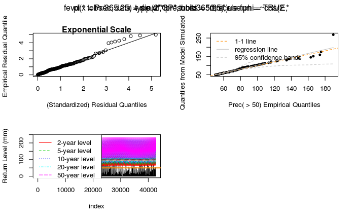

```r
plot(fit.pot2)
```

In the above plot we notice (hard to see) that there is a different return level for each day of the year. It plots return levels for different return period (1, 2, 5, 10, 20, 50…in years) for the whole time series. It is basically a repeating curve with the same return level corresponding to each day of the year.

Let’s get return levels for 10, 20 and 50 year period.

```r
rlevels <- as.data.frame(unclass(return.level(fit.pot2, c(10, 20, 50))))
rlevels["tobs"] = rf.p.df["tobs"]
rlevels["year"] = rf.p.df["year"]

print(as.matrix(rlevels), quote = FALSE, max = 100)
```

```
      10-year level 20-year level 50-year level tobs year
1          95.13590     104.90124     116.87244    1 1901
2          94.69659     104.36689     116.22158    2 1901
3          94.26247     103.83884     115.57839    3 1901
4          93.83358     103.31715     114.94295    4 1901
5          93.40998     102.80191     114.31535    5 1901
6          92.99172     102.29316     113.69567    6 1901
7          92.57884     101.79096     113.08397    7 1901
8          92.17140     101.29536     112.48031    8 1901
9          91.76943     100.80642     111.88475    9 1901
10         91.37296     100.32417     111.29734   10 1901
11         90.98202      99.84865     110.71814   11 1901
12         90.59665      99.37990     110.14718   12 1901
13         90.21686      98.91795     109.58450   13 1901
14         89.84268      98.46282     109.03012   14 1901
15         89.47414      98.01453     108.48409   15 1901
16         89.11123      97.57311     107.94642   16 1901
17         88.75398      97.13857     107.41713   17 1901
18         88.40240      96.71092     106.89623   18 1901
19         88.05649      96.29017     106.38374   19 1901
20         87.71626      95.87633     105.87966   20 1901
 [ reached getOption("max.print") -- omitted 42714 rows ]
```

So this has 42734 rows (equivalent to number of observations).  
Let’s make it into a *tidy-form* data

```r
library(reshape2)
rlevels.melt <- melt(rlevels, id.vars = c("tobs", "year"))
print(as.matrix(rlevels.melt), quote = FALSE, max = 100)
```

```
          tobs year variable      value
     [1,]   1  1901 10-year level  95.13590
     [2,]   2  1901 10-year level  94.69659
     [3,]   3  1901 10-year level  94.26247
     [4,]   4  1901 10-year level  93.83358
     [5,]   5  1901 10-year level  93.40998
     [6,]   6  1901 10-year level  92.99172
     [7,]   7  1901 10-year level  92.57884
     [8,]   8  1901 10-year level  92.17140
     [9,]   9  1901 10-year level  91.76943
    [10,]  10  1901 10-year level  91.37296
    [11,]  11  1901 10-year level  90.98202
    [12,]  12  1901 10-year level  90.59665
    [13,]  13  1901 10-year level  90.21686
    [14,]  14  1901 10-year level  89.84268
    [15,]  15  1901 10-year level  89.47414
    [16,]  16  1901 10-year level  89.11123
    [17,]  17  1901 10-year level  88.75398
    [18,]  18  1901 10-year level  88.40240
    [19,]  19  1901 10-year level  88.05649
    [20,]  20  1901 10-year level  87.71626
    [21,]  21  1901 10-year level  87.38171
    [22,]  22  1901 10-year level  87.05285
    [23,]  23  1901 10-year level  86.72966
    [24,]  24  1901 10-year level  86.41215
    [25,]  25  1901 10-year level  86.10030
 [ reached getOption("max.print") -- omitted 128177 rows ]
```

Now let’s plot the return levels for any year, for each day of the year.  
**NOTE**: The following plot will be the same for every year. This is because our non stationarity assumption for the scale parameter is considering seasonality, and not a yearly trend in precipitation.

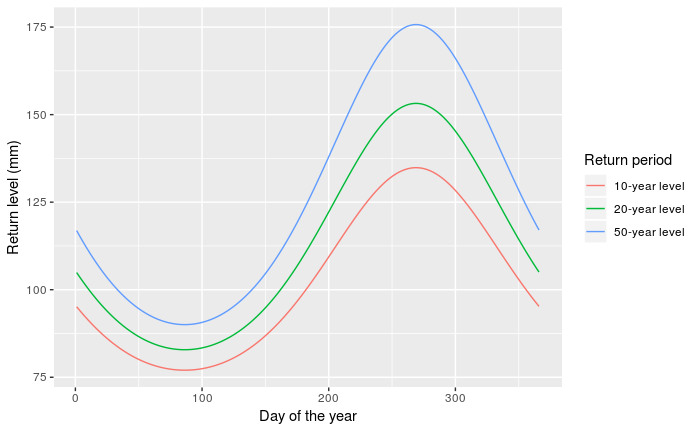

```r
library(ggplot2)
ggplot(subset(rlevels.melt, year == 2000), aes(tobs, value)) +
geom_line(aes(colour = variable)) +
xlab("Day of the year") +
ylab("Return level (mm)") +
labs(colour="Return period")
```

### Likelihood ratio test

In the same way we performed likelihood ratio test with the *more complex* Fretchet ($\mu, \sigma, \xi$) v/s the Null hypotheses i.e. the *less complex* Gumbel ($\mu, \sigma$). Here we have,  
$H_{o}$ : The scale parameter is stationary i.e. no seasonality  
$H_{a}$ : The scale parameter is non-stationary i.e. taking into account seasonality.

```r
lr.test(fit.pot1, fit.pot2)
```

```
    Likelihood-ratio Test

data:  PrecPrec
Likelihood-ratio = 8.0202, chi-square critical value = 5.9915, alpha = 0.0500, Degrees of Freedom
= 2.0000, p-value = 0.01813
alternative hypothesis: greater
```

We get a **p-value = 0.01813**. This means there is sufficient evidence to reject the null hypotheses in favour of the alternate. In other words, we will use the dsitribution with seasonally varying scale parameter to model our data.

We can derive confidence intervals for the parameters using normal approx.

```r
ci(fit.pot2, type="parameter")
```

```
fevd(x = Prec, data = rf.p.df, threshold = 50, scale.fun = ~cos(2 *
    pi * tobs/365.25) + sin(2 * pi * tobs/365.25), use.phi = TRUE,
    type = "GP", units = "mm")

[1] "Normal Approx."

      95% lower CI    Estimate 95% upper CI
phi0     2.4730819  2.99235070   3.51161955
phi1    -0.5314709 -0.04923655   0.43299776
phi2    -0.9905603 -0.57002474  -0.14948915
shape   -0.2376955 -0.09389426   0.04990701
```

However, more appropriate way of finding the confidence intervals would be to look at the trace plot and find (by hit and trial) the appropriate ranges to look for when using the profile likelihood method.

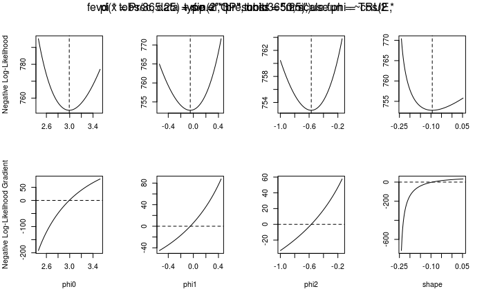

```r
plot(fit.pot2, "trace")
```

Again, I don’t exactly know how to choose a good range.

```r
ci(fit.pot2, type="parameter", which.par = 4, method="proflik", xrange = c(-0.5, 0.3))
```

```
fevd(x = Prec, data = rf.p.df, threshold = 50, scale.fun = ~cos(2 *
    pi * tobs/365.25) + sin(2 * pi * tobs/365.25), use.phi = TRUE,
    type = "GP", units = "mm")

[1] "Profile Likelihood"

[1] "shape: -0.094"

[1] "95% Confidence Interval: (-0.222, 0.0692)"
```